# W14D4 - Buccarini Giacomo Es4

```python
from sqlalchemy import create_engine
import dotenv
import os
import pandas as pd
dotenv.load_dotenv(override=True)
username = os.getenv('username')
password = os.getenv('password')
host = os.getenv('host')
dbname = os.getenv('dbname')

import pandas as pd
dbname = "AdventureWorksDW"
conn_string = f"mysql+pymysql://{username}:{password}@{host}/{dbname}"
db_engine = create_engine(conn_string)
query = """SELECT *
        FROM dimproduct
        """
df = pd.read_sql(query, db_engine)
```

```python
df
```

|  | ProductKey | ProductAlternateKey | ProductSubcategoryKey | WeightUnitMeasureCode | SizeUnitMeasureCode | EnglishProductName | SpanishProductName | FrenchProductName | StandardCost | FinishedGoodsFlag | ... | ChineseDescription | ArabicDescription | HebrewDescription | ThaiDescription | GermanDescription | JapaneseDescription | TurkishDescription | StartDate | EndDate | Status |
| --- | --- | --- | --- | --- | --- | --- | --- | --- | --- | --- | --- | --- | --- | --- | --- | --- | --- | --- | --- | --- | --- |
| 0 | 1 | AR-5381 | NaN | None | None | Adjustable Race |  |  | NaN | 0 | ... | None | None | None | None | None | None | None | 2003-07-01 | NaT | Current |
| 1 | 2 | BA-8327 | NaN | None | None | Bearing Ball |  |  | NaN | 0 | ... | None | None | None | None | None | None | None | 2003-07-01 | NaT | Current |
| 2 | 3 | BE-2349 | NaN | None | None | BB Ball Bearing |  |  | NaN | 0 | ... | None | None | None | None | None | None | None | 2003-07-01 | NaT | Current |
| 3 | 4 | BE-2908 | NaN | None | None | Headset Ball Bearings |  |  | NaN | 0 | ... | None | None | None | None | None | None | None | 2003-07-01 | NaT | Current |
| 4 | 5 | BL-2036 | NaN | None | None | Blade |  |  | NaN | 0 | ... | None | None | None | None | None | None | None | 2003-07-01 | NaT | Current |
| ... | ... | ... | ... | ... | ... | ... | ... | ... | ... | ... | ... | ... | ... | ... | ... | ... | ... | ... | ... | ... | ... |
| 601 | 602 | BB-8107 | 5.0 | G | None | ML Bottom Bracket | Eje de pedalier GM | Axe de pédalier ML | 44.95 | 1 | ... | 铝合金车圈；大直径脚蹬轴。 | فناجين من سبيكة الألومنيوم؛ ذات محور دوران كبي... | כיסויים מסגסוגת אלומיניום; ציר רחב-קוטר. | ดุมอลูมิเนียมอัลลอยด์ แกนเพลาขนาดใหญ่ | Außenringe aus Aluminiumlegierung; Radachse mi... | アルミニウム合金カップ、大径スピンドル。 | Alüminyum alaşımı orta göbekler; geniş çaplı mil. | 2013-07-01 | NaT | Current |
| 602 | 603 | BB-9108 | 5.0 | G | None | HL Bottom Bracket | Eje de pedalier GA | Axe de pédalier HL | 53.94 | 1 | ... | 铝合金车圈和空心轴。 | فناجين من سبيكة الألومنيوم ومحور أجوف. | כיסויים מסגסוגת אלומיניום וציר חלול. | ดุมอลูมิเนียมอัลลอยด์และเพลากลวง | Außenringe aus Aluminiumlegierung und hohle Ac... | アルミニウム合金カップとホロー アクスル。 | Alüminyum alaşımı orta göbekler ve içi boş aks. | 2013-07-01 | NaT | Current |
| 603 | 604 | BK-R19B-44 | 2.0 | LB | CM | Road-750 Black, 44 | Carretera: 750, negra, 44 | Vélo de route 750 noir, 44 | 343.65 | 1 | ... | 入门级成人自行车；确保越野旅行或公路骑乘的舒适。快拆式车毂和轮缘。 | إنها دراجة مناسبة للمبتدئين من البالغين؛ فهي ت... | אופני מבוגרים למתחילים; מציעים רכיבה נוחה "מחו... | จักรยานระดับเริ่มต้นสำหรับผู้ใหญ่ ให้ความสบายใ... | Ein Erwachsenenrad für Einsteiger; bietet Komf... | エントリー レベルに対応する、クロスカントリーにも街への買い物にも快適な、大人の自転車。ハブ... | "Başlangıç seviyesinde yetişkin bisikleti, kır... | 2013-07-01 | NaT | Current |
| 604 | 605 | BK-R19B-48 | 2.0 | LB | CM | Road-750 Black, 48 | Carretera: 750, negra, 48 | Vélo de route 750 noir, 48 | 343.65 | 1 | ... | 入门级成人自行车；确保越野旅行或公路骑乘的舒适。快拆式车毂和轮缘。 | إنها دراجة مناسبة للمبتدئين من البالغين؛ فهي ت... | אופני מבוגרים למתחילים; מציעים רכיבה נוחה "מחו... | จักรยานระดับเริ่มต้นสำหรับผู้ใหญ่ ให้ความสบายใ... | Ein Erwachsenenrad für Einsteiger; bietet Komf... | エントリー レベルに対応する、クロスカントリーにも街への買い物にも快適な、大人の自転車。ハブ... | "Başlangıç seviyesinde yetişkin bisikleti, kır... | 2013-07-01 | NaT | Current |
| 605 | 606 | BK-R19B-52 | 2.0 | LB | CM | Road-750 Black, 52 | Carretera: 750, negra, 52 | Vélo de route 750 noir, 52 | 343.65 | 1 | ... | 入门级成人自行车；确保越野旅行或公路骑乘的舒适。快拆式车毂和轮缘。 | إنها دراجة مناسبة للمبتدئين من البالغين؛ فهي ت... | אופני מבוגרים למתחילים; מציעים רכיבה נוחה "מחו... | จักรยานระดับเริ่มต้นสำหรับผู้ใหญ่ ให้ความสบายใ... | Ein Erwachsenenrad für Einsteiger; bietet Komf... | エントリー レベルに対応する、クロスカントリーにも街への買い物にも快適な、大人の自転車。ハブ... | "Başlangıç seviyesinde yetişkin bisikleti, kır... | 2013-07-01 | NaT | Current |

606 rows × 36 columns

Esercizio 1/3 Estraiamo la tabella dimproduct dal database AdventureWorks, e valutiamo quanto segue: 1 • Quanti dati ci sono in totale? 2 • Quali sono i metadati? 3 • Stampiamo il primo elemento 4 • Stampiamo l'ultimo elemento 5 • Riusciamo a stampare cinque elementi a caso? 6 • Quali sono i colori disponibili?

```python
df.shape # 1
```

```
(606, 36)
```

```python
df.columns # 2
```

```
Index(['ProductKey', 'ProductAlternateKey', 'ProductSubcategoryKey',
       'WeightUnitMeasureCode', 'SizeUnitMeasureCode', 'EnglishProductName',
       'SpanishProductName', 'FrenchProductName', 'StandardCost',
       'FinishedGoodsFlag', 'Color', 'SafetyStockLevel', 'ReorderPoint',
       'ListPrice', 'Size', 'SizeRange', 'Weight', 'DaysToManufacture',
       'ProductLine', 'DealerPrice', 'Class', 'Style', 'ModelName',
       'LargePhoto', 'EnglishDescription', 'FrenchDescription',
       'ChineseDescription', 'ArabicDescription', 'HebrewDescription',
       'ThaiDescription', 'GermanDescription', 'JapaneseDescription',
       'TurkishDescription', 'StartDate', 'EndDate', 'Status'],
      dtype='object')
```

```python
df.head(1) # 3
```

|  | ProductKey | ProductAlternateKey | ProductSubcategoryKey | WeightUnitMeasureCode | SizeUnitMeasureCode | EnglishProductName | SpanishProductName | FrenchProductName | StandardCost | FinishedGoodsFlag | ... | ChineseDescription | ArabicDescription | HebrewDescription | ThaiDescription | GermanDescription | JapaneseDescription | TurkishDescription | StartDate | EndDate | Status |
| --- | --- | --- | --- | --- | --- | --- | --- | --- | --- | --- | --- | --- | --- | --- | --- | --- | --- | --- | --- | --- | --- |
| 0 | 1 | AR-5381 | NaN | None | None | Adjustable Race |  |  | NaN | 0 | ... | None | None | None | None | None | None | None | 2003-07-01 | NaT | Current |

1 rows × 36 columns

```python
df.tail(1) # 4
```

|  | ProductKey | ProductAlternateKey | ProductSubcategoryKey | WeightUnitMeasureCode | SizeUnitMeasureCode | EnglishProductName | SpanishProductName | FrenchProductName | StandardCost | FinishedGoodsFlag | ... | ChineseDescription | ArabicDescription | HebrewDescription | ThaiDescription | GermanDescription | JapaneseDescription | TurkishDescription | StartDate | EndDate | Status |
| --- | --- | --- | --- | --- | --- | --- | --- | --- | --- | --- | --- | --- | --- | --- | --- | --- | --- | --- | --- | --- | --- |
| 605 | 606 | BK-R19B-52 | 2.0 | LB | CM | Road-750 Black, 52 | Carretera: 750, negra, 52 | Vélo de route 750 noir, 52 | 343.65 | 1 | ... | 入门级成人自行车；确保越野旅行或公路骑乘的舒适。快拆式车毂和轮缘。 | إنها دراجة مناسبة للمبتدئين من البالغين؛ فهي ت... | אופני מבוגרים למתחילים; מציעים רכיבה נוחה "מחו... | จักรยานระดับเริ่มต้นสำหรับผู้ใหญ่ ให้ความสบายใ... | Ein Erwachsenenrad für Einsteiger; bietet Komf... | エントリー レベルに対応する、クロスカントリーにも街への買い物にも快適な、大人の自転車。ハブ... | "Başlangıç seviyesinde yetişkin bisikleti, kır... | 2013-07-01 | NaT | Current |

1 rows × 36 columns

```python
df.sample(5) # 5
```

|  | ProductKey | ProductAlternateKey | ProductSubcategoryKey | WeightUnitMeasureCode | SizeUnitMeasureCode | EnglishProductName | SpanishProductName | FrenchProductName | StandardCost | FinishedGoodsFlag | ... | ChineseDescription | ArabicDescription | HebrewDescription | ThaiDescription | GermanDescription | JapaneseDescription | TurkishDescription | StartDate | EndDate | Status |
| --- | --- | --- | --- | --- | --- | --- | --- | --- | --- | --- | --- | --- | --- | --- | --- | --- | --- | --- | --- | --- | --- |
| 122 | 123 | LN-1428 | NaN | None | None | Lock Nut 9 |  |  | NaN | 0 | ... | None | None | None | None | None | None | None | 2003-07-01 | NaT | Current |
| 556 | 557 | CS-6583 | 8.0 | G | None | ML Crankset | Bielas GM | Pédalier ML | 113.88 | 1 | ... | 高强度的曲臂。 | ذراع تدوير شديد القوة. | זרוע ארכובה עתירת עוצמה. | คันบังคับแข็งแรงเป็นพิเศษ | Robuster Pedalarm. | 高強度クランク アーム。 | Çok güçlü krank kolu. | 2013-07-01 | NaT | Current |
| 377 | 378 | BK-R89B-52 | 2.0 | LB | CM | Road-250 Black, 52 | Carretera: 250, negra, 52 | Vélo de route 250 noir, 52 | 1554.95 | 1 | ... | 铝合金车架确保骑乘轻快、稳固，可用于室内比赛或参加俱乐部的越野活动。 | يوفر الهيكل المصنوع من سبيكة ألومنيوم قيادة قو... | מסגרת מסגסוגת אלומיניום מספקת רכיבה קלה ומוצקה... | เฟรมอลูมิเนียมอัลลอยด์ ให้การขับขี่ที่เบา มั่น... | Der Rahmen aus Aluminiumlegierung bietet leich... | レース トラックの走行でもオフロードのツーリングでも、アルミニウム合金のフレームにより、軽さ... | "Alüminyum alaşımı kadro, ister velodromda yar... | 2013-07-01 | NaT | Current |
| 300 | 301 | FR-M94B-46 | 12.0 | LB | CM | HL Mountain Frame - Black, 46 |  |  | 617.03 | 1 | ... | 每个车架都是在我们位于 Bothell 的工厂中手工制作，具有高质量山地车架所必需的最佳直径... | وقد تم تصنيع كل هيكل من تلك الهياكل يدويًا في ... | כל מסגרת מיוצרת ידנית במפעל שלנו ב- Bothell, ל... | เฟรมแต่ละชิ้นผ่านการสร้างด้วยมือในโรงงาน Bothe... | "Jeder Rahmen wird in unserem Werk in Braunsfe... | 各フレームは、Bothell 工場で最高級のマウンテン バイクのフレームに必要な最適径および... | "Her bir kadro Bothell tesisimizde, birinci sı... | 2011-07-01 | 2007-12-28 | None |
| 29 | 30 | FW-9160 | NaN | None | None | Flat Washer 7 |  |  | NaN | 0 | ... | None | None | None | None | None | None | None | 2003-07-01 | NaT | Current |

5 rows × 36 columns

```python
df.loc[:, "Color"].unique() # 6
```

```
array(['NA', 'Black', 'Silver', 'Red', 'White', 'Blue', 'Multi', 'Yellow',
       'Grey', 'Silver/Black'], dtype=object)
```

7 • In media quanto pesano i prodotti? 8 • Quanto pesa il più leggero? 9 • Quanto pesa il più pesante? 10 • Quanti prodotti pesano più di 100 Kg? 11 • Quanto costano in media i prodotti (colonna DealerPrice)? 12 • Se prendiamo un quarto di tutti i prodotti, in modo che siano i più costosi, quale sarà il loro range di prezzo?

```python
df.loc[:, "Weight"].mean() # 7
```

```
56.1932269503546
```

```python
df["Weight"].describe() # 7(alternativa) - 8 - 9
```

```
count     282.000000
mean       56.193227
std       158.000652
min         2.120000
25%         2.680000
50%        15.420000
75%        24.130000
max      1050.000000
Name: Weight, dtype: float64
```

```python
filtro_peso = df["Weight"] > 100 # masking 10
```

```python
df.loc [filtro_peso] # 10
```

|  | ProductKey | ProductAlternateKey | ProductSubcategoryKey | WeightUnitMeasureCode | SizeUnitMeasureCode | EnglishProductName | SpanishProductName | FrenchProductName | StandardCost | FinishedGoodsFlag | ... | ChineseDescription | ArabicDescription | HebrewDescription | ThaiDescription | GermanDescription | JapaneseDescription | TurkishDescription | StartDate | EndDate | Status |
| --- | --- | --- | --- | --- | --- | --- | --- | --- | --- | --- | --- | --- | --- | --- | --- | --- | --- | --- | --- | --- | --- |
| 179 | 180 | RM-M464 | NaN | G | None | LL Mountain Rim |  |  | NaN | 0 | ... | None | None | None | None | None | None | None | 2003-07-01 | NaT | Current |
| 180 | 181 | RM-M692 | NaN | G | None | ML Mountain Rim |  |  | NaN | 0 | ... | None | None | None | None | None | None | None | 2003-07-01 | NaT | Current |
| 181 | 182 | RM-M823 | NaN | G | None | HL Mountain Rim |  |  | NaN | 0 | ... | None | None | None | None | None | None | None | 2003-07-01 | NaT | Current |
| 182 | 183 | RM-R436 | NaN | G | None | LL Road Rim |  |  | NaN | 0 | ... | None | None | None | None | None | None | None | 2003-07-01 | NaT | Current |
| 183 | 184 | RM-R600 | NaN | G | None | ML Road Rim |  |  | NaN | 0 | ... | None | None | None | None | None | None | None | 2003-07-01 | NaT | Current |
| 184 | 185 | RM-R800 | NaN | G | None | HL Road Rim |  |  | NaN | 0 | ... | None | None | None | None | None | None | None | 2003-07-01 | NaT | Current |
| 185 | 186 | RM-T801 | NaN | G | None | Touring Rim |  |  | NaN | 0 | ... | None | None | None | None | None | None | None | 2003-07-01 | NaT | Current |
| 412 | 413 | FW-R623 | 17.0 | G | None | LL Road Front Wheel | Rueda de carretera delantera GB | Roue avant de vélo de route LL | 37.99 | 1 | ... | 适用于入门级骑乘者的公路型备用前轮。 | عجلة طريق أمامية بديلة لقائدي الدراجات المبتدئين. | גלגל חלופי קדמי לרכיבת כביש לרוכב המתחיל. | ล้อหน้าจักรยานภูเขาอะไหล่สำหรับนักปั่นระดับเริ... | Ersatzvorderrad für Einsteiger. | 初心者向けの交換用フロント ロード ホイール。 | Başlangıç seviyesindeki sürücüler için yedek ö... | 2012-07-01 | 2008-12-27 | None |
| 413 | 414 | FW-R762 | 17.0 | G | None | ML Road Front Wheel | Rueda de carretera delantera GM | Roue avant de vélo de route ML | 110.28 | 1 | ... | 坚固的合金具有快拆式车毂。 | تتميز بوجود سبيكة قوية تحتوي على محور عجلة سري... | סגסוגת איתנה מאפיינת את מנגנון השחרור המהיר של... | ดุมล้ออัลลอยด์ที่ทนทาน ถอดได้อย่างรวดเร็ว | Robustes Design mit Schnellspann-Nabe. | 頑丈な合金による、クイックリリース ハブ。 | "Dayanıklı alaşım, kolay sökülebilen göbek içe... | 2012-07-01 | 2008-12-27 | None |
| 414 | 415 | FW-R820 | 17.0 | G | None | HL Road Front Wheel | Rueda de carretera delantera GA | Roue avant de vélo de route HL | 146.55 | 1 | ... | 具有双层轮缘的坚固车轮。 | عجلة قوية بإطار معدني ذي طبقتين. | גלגל חזק עם חישוק בעל הלחמה כפולה. | ล้อที่แข็งแกร่งพร้อมขอบล้อผนังสองชั้น | Starkes Rad mit doppelt beschichteter Felge. | ダブルウォール リムを持つ頑丈なホイール。 | İki duvarlı jantlı güçlü tekerlek. | 2012-07-01 | 2008-12-27 | None |
| 421 | 422 | RW-R623 | 17.0 | G | None | LL Road Rear Wheel | Rueda de carretera trasera GB | Roue arrière de vélo de route LL | 49.98 | 1 | ... | 适用于入门级骑乘者的公路型备用前轮。 | عجلة طريق أمامية بديلة لقائدي الدراجات المبتدئين. | גלגל חלופי קדמי לרכיבת כביש לרוכב המתחיל. | ล้อหน้าจักรยานภูเขาอะไหล่สำหรับนักปั่นระดับเริ... | Ersatzhinterrad für Einsteiger. | 初心者向けの交換用リア ロード ホイール。 | Başlangıç seviyesinde sürücüler için yedek ark... | 2012-07-01 | 2008-12-27 | None |
| 422 | 423 | RW-R762 | 17.0 | G | None | ML Road Rear Wheel | Rueda de carretera trasera GM | Roue arrière de vélo de route ML | 122.27 | 1 | ... | 带不锈钢辐条的铝合金轮缘；特别为提速而设计。 | إطار معدني مصنوع من سبيكة الألومنيوم بقضبان شع... | חישוק מסגסוגת אלומיניום עם חישורים מפלדת אל-חל... | ขอบอลูมิเนียมอัลลอยด์พร้อมซี่ล้อสเตนเลส สำหรับ... | Felge aus Aluminiumlegierung mit Speichen aus ... | 高速走行用のステンレス製スポークを備えたアルミニウム合金リム。 | Paslanmaz çelik telli alüminyum alaşımı jantla... | 2012-07-01 | 2008-12-27 | None |
| 423 | 424 | RW-R820 | 17.0 | G | None | HL Road Rear Wheel | Rueda de carretera trasera GA | Roue arrière de vélo de route HL | 158.53 | 1 | ... | 具有双层轮缘的坚固后轮。 | عجلة خلفية قوية بإطار معدني ذي طبقتين. | גלגל אחורי חזק עם חישוק בעל הלחמה כפולה. | ล้อหลังที่แข็งแกร่งพร้อมขอบล้อผนังสองชั้น | Starkes Hinterrad mit doppelt beschichteter Fe... | ダブルウォール リムを持つ頑丈なリア ホイール。 | İki duvarlı jantlı güçlü arka tekerlek. | 2012-07-01 | 2008-12-27 | None |
| 500 | 501 | RD-2308 | 9.0 | G | None | Rear Derailleur | Desviador trasero | Dérailleur arrière | 53.93 | 1 | ... | 宽连杆设计。 | تصميم عريض الوصلات. | עיצוב רחב-חוליות. | การออกแบบให้มีจุดเชื่อมกว้าง | Wide-Link-Design. | ワイドリンク デザイン。 | Geniş bağlantılı tasarım. | 2013-07-01 | NaT | Current |
| 513 | 514 | RB-9231 | 6.0 | G | None | Rear Brakes | Frenos traseros | Freins arrière | 47.29 | 1 | ... | None | None | None | None | None | None | None | 2013-07-01 | NaT | Current |
| 541 | 542 | PD-M282 | 13.0 | G | None | LL Mountain Pedal | Pedal de montaña GB | Pédale de VTT LL | 17.98 | 1 | ... | 展开式踏板便于您穿任何鞋子骑乘；适用于各种情况。 | هيكل أساسي واسع بحيث يمكنك القيادة بأي حذاء، و... | משטח דוושות מורחב המתאים לרכיבה בכל סוגי הנעלי... | คันถีบขนาดใหญ่ สำหรับการขับขี่ด้วยรองเท้าชนิดใ... | Größere Fläche für Komfort in allen Schuhen. | 靴を選ばない拡張プラットフォームなので、オールラウンド ライディングに最適です。 | "Geniş pedalı sayesinde her tür ayakkabıyla sü... | 2013-07-01 | NaT | Current |
| 542 | 543 | PD-M340 | 13.0 | G | None | ML Mountain Pedal | Pedal de montaña GM | Pédale de VTT ML | 27.57 | 1 | ... | 无扣带式脚踏轻型耐用且松紧可调。 | دواسة خفيفة الوزن شديدة التحمّل بلا مشابك وذات... | דוושה עמידה נטולת חבקים עם מאמץ מתכוונן. | คันถีบน้ำหนักเบา ทนทาน ไม่มีคลิป และสามารถปรับ... | Leichte Pedale ohne Pedalhaken mit anpassbarer... | 軽量で耐久性に優れ、テンション調整が可能なクリップレス ペダル。 | "Hafif, dayanıklı klipssiz pedal, gerginliği a... | 2013-07-01 | NaT | Current |
| 543 | 544 | PD-M562 | 13.0 | G | None | HL Mountain Pedal | Pedal de montaña GA | Pédale de VTT HL | 35.96 | 1 | ... | 不锈钢材质；易于去泥。 | مصنوعة من الفولاذ الذي لا يصدأ، والذي تم تصميم... | פלדת אל-חלד; עיצוב המשיר בוץ בקלות. | โลหะสเตนเลส ได้รับการออกแบบให้สลัดโคลนออกได้ง่าย | Edelstahl; schmutzabweisendes Design. | ステンレス製で、泥を簡単に払い落せるデザインです。 | "Paslanmaz çelik, çamuru üzerinden kolayca ata... | 2013-07-01 | NaT | Current |
| 544 | 545 | PD-R347 | 13.0 | G | None | LL Road Pedal | Pedal de carretera GB | Pédale de vélo de route LL | 17.98 | 1 | ... | 无扣带式脚踏 – 铝制。 | دواستان بلا مشابك مصنوعتان من الألومنيوم. | דוושות ללא חבקים – אלומיניום. | คันถีบไม่มีคลิป - อลูมิเนียม | Pedale ohne Pedalhaken - Aluminium. | クリップレス ペダル (アルミニウム)。 | Klipssiz pedallar - alüminyum. | 2013-07-01 | NaT | Current |
| 545 | 546 | PD-R563 | 13.0 | G | None | ML Road Pedal | Pedal de carretera GM | Pédale de vélo de route ML | 27.57 | 1 | ... | 轻型铝合金结构。 | تركيبة سبيكة ألومنيوم خفيفة الوزن. | מבנה סגסוגת אלומיניום קל משקל. | โครงสร้างอลูมิเนียมอัลลอยด์น้ำหนักเบา | Leichte Aluminiumlegierung. | 軽量アルミニウム合金構造。 | Hafif alüminyum alaşımı konstrüksiyon. | 2013-07-01 | NaT | Current |
| 546 | 547 | PD-R853 | 13.0 | G | None | HL Road Pedal | Pedal de carretera GA | Pédale de vélo de route HL | 35.96 | 1 | ... | 松紧可调的高档无扣带式脚踏。 | دواستان من أعلى الطرازات بقوة شدّ يمكن تعديلها. | דוושות נטולות חבקים מהשורה הראשונה עם מאמץ מתכ... | คันถีบระดับเยี่ยม ไม่มีคลิป ปรับความตึงได้ | Top-Pedale ohne Pedalhaken mit anpassbarer Spa... | テンション調整が可能な最高級クリップレス ペダル。 | Gerginliği ayarlanabilen gerginlikli en üst sı... | 2013-07-01 | NaT | Current |
| 554 | 555 | FB-9873 | 6.0 | G | None | Front Brakes | Frenos delanteros | Freins avant | 47.29 | 1 | ... | 全天候刹车垫；通过增加与轮缘的接触面积来提供优异的制动功能。 | تحتوي على بطانات (تيل) فرامل، تناسب كافة الظرو... | רפידות מעצור המתאימות לכל מזג אוויר; מספקות עצ... | ยางเบรกสำหรับทุกสภาพอากาศ เพื่อการหยุดที่มั่นใ... | Allwetter-Bremsbeläge für erstklassiges Bremse... | 全天候型ブレーキ パッドを採用し、リムに広い表面積を適用することにより優れた制動力を提供します。 | "Tüm hava durumlarına uygun fren pedleri, jant... | 2013-07-01 | NaT | Current |
| 555 | 556 | CS-4759 | 8.0 | G | None | LL Crankset | Bielas GB | Pédalier LL | 77.92 | 1 | ... | 极其坚实的脚踏轴。 | محور دوران صلب فائق الأداء. | ציר קשיח במיוחד. | เพลาล้อสุดแกร่ง | Extrem robuste Achse. | 最強の剛性を誇るスピンドル。 | Çok sağlam mil. | 2013-07-01 | NaT | Current |
| 556 | 557 | CS-6583 | 8.0 | G | None | ML Crankset | Bielas GM | Pédalier ML | 113.88 | 1 | ... | 高强度的曲臂。 | ذراع تدوير شديد القوة. | זרוע ארכובה עתירת עוצמה. | คันบังคับแข็งแรงเป็นพิเศษ | Robuster Pedalarm. | 高強度クランク アーム。 | Çok güçlü krank kolu. | 2013-07-01 | NaT | Current |
| 557 | 558 | CS-9183 | 8.0 | G | None | HL Crankset | Bielas GA | Pédalier HL | 179.82 | 1 | ... | 三重齿盘；铝制曲臂；完美变速。 | مجموعة تدوير ثلاثية، وذراع تدوير ألومنيوم، وإم... | ערכת ארכובה משולשת, זרוע ארכובה מאלומיניום, חי... | ชุดควบคุมสามชั้น คันบังคับอลูมิเนียม และการเปล... | Dreifach-Kurbelsatz; Aluminium-Pedalarm; tadel... | トリプル クランクセット、アルミニウム クランク アーム、完璧なシフト。 | "Üçlü ruble, alüminyum krank kolu, takılmadan ... | 2013-07-01 | NaT | Current |
| 600 | 601 | BB-7421 | 5.0 | G | None | LL Bottom Bracket | Eje de pedalier GB | Axe de pédalier LL | 23.97 | 1 | ... | 铬钢。 | الفولاذ الكرومولي | פלדת כרומולי (כרום-מולובדניום) | โลหะโครโมลี | Chromstahl. | クロム鋼。 | Kromoli çelik. | 2013-07-01 | NaT | Current |
| 601 | 602 | BB-8107 | 5.0 | G | None | ML Bottom Bracket | Eje de pedalier GM | Axe de pédalier ML | 44.95 | 1 | ... | 铝合金车圈；大直径脚蹬轴。 | فناجين من سبيكة الألومنيوم؛ ذات محور دوران كبي... | כיסויים מסגסוגת אלומיניום; ציר רחב-קוטר. | ดุมอลูมิเนียมอัลลอยด์ แกนเพลาขนาดใหญ่ | Außenringe aus Aluminiumlegierung; Radachse mi... | アルミニウム合金カップ、大径スピンドル。 | Alüminyum alaşımı orta göbekler; geniş çaplı mil. | 2013-07-01 | NaT | Current |
| 602 | 603 | BB-9108 | 5.0 | G | None | HL Bottom Bracket | Eje de pedalier GA | Axe de pédalier HL | 53.94 | 1 | ... | 铝合金车圈和空心轴。 | فناجين من سبيكة الألومنيوم ومحور أجوف. | כיסויים מסגסוגת אלומיניום וציר חלול. | ดุมอลูมิเนียมอัลลอยด์และเพลากลวง | Außenringe aus Aluminiumlegierung und hohle Ac... | アルミニウム合金カップとホロー アクスル。 | Alüminyum alaşımı orta göbekler ve içi boş aks. | 2013-07-01 | NaT | Current |

28 rows × 36 columns

```python
df["DealerPrice"].mean() # 11
```

```
448.5970597468353
```

```python
df["DealerPrice"].describe() # 11 (mean) - 12 (dal 75 al max)
```

```
count     395.000000
mean      448.597060
std       503.225071
min         1.374000
25%        41.994000
50%       218.454000
75%       722.594900
max      2146.962000
Name: DealerPrice, dtype: float64
```

13 • Qual è il prezzo medio per i prodotti di colore blu? 14 • Qual è il prezzo medio per i prodotti di colore rosso o nero? 15 • Qual è il prezzo massimo per i prodotti di taglia 42 e peso oltre i 10 Kg? 16 • Qual è il nome inglese e il costo di produzione (StandardCost) di tutti i prodotti di taglia 42, peso oltre i 10 Kg e colore argento? 17 • Esaminiamo la differenza tra lo StandardCost e il DealerPrice degli ultimi 20 elementi del dataset: c'è un pattern? SI C'è qualche elemento che non lo segue? In questi punti 603-604-605 non viene rispettato.

```python
filtro_colore = df["Color"] == "Blue"  # 13
df_blue = df.loc [filtro_colore]
df_blue.head()
```

|  | ProductKey | ProductAlternateKey | ProductSubcategoryKey | WeightUnitMeasureCode | SizeUnitMeasureCode | EnglishProductName | SpanishProductName | FrenchProductName | StandardCost | FinishedGoodsFlag | ... | ChineseDescription | ArabicDescription | HebrewDescription | ThaiDescription | GermanDescription | JapaneseDescription | TurkishDescription | StartDate | EndDate | Status |
| --- | --- | --- | --- | --- | --- | --- | --- | --- | --- | --- | --- | --- | --- | --- | --- | --- | --- | --- | --- | --- | --- |
| 219 | 220 | HL-U509-B | 31.0 | None | None | Sport-100 Helmet, Blue | Casco deportivo: 100, azul | Casque sport 100, bleu | 12.03 | 1 | ... | 通用型透气良好且轻便，带有自合型帽沿。 | ملائمة بشكل عام، وجيدة التهوية، وخفيفة الوزن ب... | מידה אונברסלית, מאווררת היטב, קלת-משקל, עם מצח... | แว่นกันลมขนาดสากล ระบายอากาศได้ดี น้ำหนักเบา | "Einheitsgröße, atmungsaktiv, leicht, aufsetzb... | 軽量で通気性に優れたユニバーサル フィットのスナップ オン バイザー。 | "Her bisiklete kolayca takılabilen, aerodinami... | 2011-07-01 | 2007-12-28 | None |
| 220 | 221 | HL-U509-B | 31.0 | None | None | Sport-100 Helmet, Blue | Casco deportivo: 100, azul | Casque sport 100, bleu | 13.88 | 1 | ... | 通用型透气良好且轻便，带有自合型帽沿。 | ملائمة بشكل عام، وجيدة التهوية، وخفيفة الوزن ب... | מידה אונברסלית, מאווררת היטב, קלת-משקל, עם מצח... | แว่นกันลมขนาดสากล ระบายอากาศได้ดี น้ำหนักเบา | "Einheitsgröße, atmungsaktiv, leicht, aufsetzb... | 軽量で通気性に優れたユニバーサル フィットのスナップ オン バイザー。 | "Her bisiklete kolayca takılabilen, aerodinami... | 2012-07-01 | 2008-12-27 | None |
| 221 | 222 | HL-U509-B | 31.0 | None | None | Sport-100 Helmet, Blue | Casco deportivo: 100, azul | Casque sport 100, bleu | 13.09 | 1 | ... | 通用型透气良好且轻便，带有自合型帽沿。 | ملائمة بشكل عام، وجيدة التهوية، وخفيفة الوزن ب... | מידה אונברסלית, מאווררת היטב, קלת-משקל, עם מצח... | แว่นกันลมขนาดสากล ระบายอากาศได้ดี น้ำหนักเบา | "Einheitsgröße, atmungsaktiv, leicht, aufsetzb... | 軽量で通気性に優れたユニバーサル フィットのスナップ オン バイザー。 | "Her bisiklete kolayca takılabilen, aerodinami... | 2013-07-01 | NaT | Current |
| 470 | 471 | VE-C304-S | 25.0 | None | None | Classic Vest, S | Camiseta clásica, P | Veste classique, taille S | 23.75 | 1 | ... | 轻型抗风，可折叠放入口袋。 | علب خفيفة الوزن، ومقاومة للريح، تناسب حجم الجيب. | קל-משקל, מגן מרוח, מתקפל לגודל המתאים לכיס. | น้ำหนักเบา กันลม ขนาดกะทัดรัดพอดีกระเป๋า | "Leicht, windabweisend, passt in kleine Tasche." | ポケットに収まる軽量耐風性パック。 | "Hafif, rüzgar geçirmez, katlandığında cebe sı... | 2013-07-01 | NaT | Current |
| 471 | 472 | VE-C304-M | 25.0 | None | None | Classic Vest, M | Camiseta clásica, M | Veste classique, taille M | 23.75 | 1 | ... | 轻型抗风，可折叠放入口袋。 | علب خفيفة الوزن، ومقاومة للريح، تناسب حجم الجيب. | קל-משקל, מגן מרוח, מתקפל לגודל המתאים לכיס. | น้ำหนักเบา กันลม ขนาดกะทัดรัดพอดีกระเป๋า | "Leicht, windabweisend, passt in kleine Tasche." | ポケットに収まる軽量耐風性パック。 | "Hafif, rüzgar geçirmez, katlandığında cebe sı... | 2013-07-01 | NaT | Current |

5 rows × 36 columns

```python
filtro_rosso = df["Color"] == "Red"  # 14
filtro_nero = df["Color"] == "Black"
df_rosso_nero = df.loc[filtro_rosso |filtro_nero]
df_rosso_nero["Color"].unique()
```

```
array(['Black', 'Red'], dtype=object)
```

```python
df_rosso_nero["DealerPrice"].mean()  # 14
```

```
550.2481873684211
```

```python
filtro_taglia = df["Size"] == "42"  # 15
filtro_peso = df["Weight"] > 10
df_42_10 = df.loc[filtro_taglia & filtro_peso]
df_42_10["DealerPrice"].describe()
```

```
count      12.000000
mean     1060.343267
std       599.030160
min       323.994000
25%       565.620375
50%      1125.026450
75%      1380.744000
max      2039.994000
Name: DealerPrice, dtype: float64
```

```python
filtro_argento = df["Color"] == "Silver"    # 16
df_42_10_sil = df.loc[filtro_taglia & filtro_peso & filtro_argento]
df_42_10_sil[["EnglishProductName", "StandardCost"]]
```

|  | EnglishProductName | StandardCost |
| --- | --- | --- |
| 344 | Mountain-100 Silver, 42 | 1912.15 |
| 353 | Mountain-200 Silver, 42 | 1117.86 |
| 354 | Mountain-200 Silver, 42 | 1265.62 |
| 588 | Mountain-400-W Silver, 42 | 419.78 |
| 591 | Mountain-500 Silver, 42 | 308.22 |

```python
 df[["StandardCost","DealerPrice"]].tail(20) # 17
```

|  | StandardCost | DealerPrice |
| --- | --- | --- |
| 586 | 419.78 | 461.694 |
| 587 | 419.78 | 461.694 |
| 588 | 419.78 | 461.694 |
| 589 | 419.78 | 461.694 |
| 590 | 308.22 | 338.994 |
| 591 | 308.22 | 338.994 |
| 592 | 308.22 | 338.994 |
| 593 | 308.22 | 338.994 |
| 594 | 308.22 | 338.994 |
| 595 | 294.58 | 323.994 |
| 596 | 294.58 | 323.994 |
| 597 | 294.58 | 323.994 |
| 598 | 294.58 | 323.994 |
| 599 | 294.58 | 323.994 |
| 600 | 23.97 | 32.394 |
| 601 | 44.95 | 60.744 |
| 602 | 53.94 | 72.894 |
| 603 | 343.65 | 323.994 |
| 604 | 343.65 | 323.994 |
| 605 | 343.65 | 323.994 |

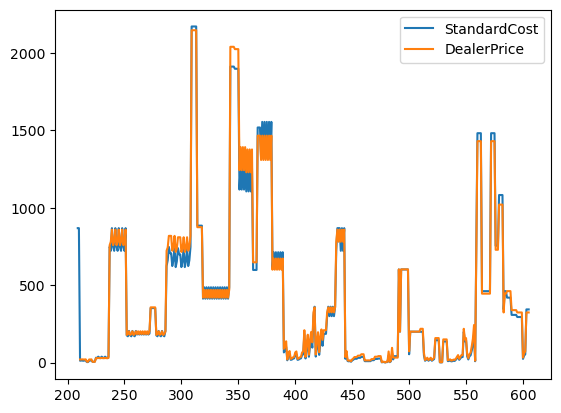

```python
 df[["StandardCost","DealerPrice"]].plot()
```

Esercizio Tra i beginner datasets scaricabili all'indirizzo https://www.kaggle.com/datasets/ahmettezcantekin/beginner-datasets selezioniamo amazon.csv, un dataset contenente una serie di recensioni su Amazon. 18 • Valutiamo la dimensione del dataset 19 • Visualizziamo dieci righe a caso; 20 • Osserviamo quali sono i nomi di colonna; 21 • Il dataset è bilanciato, ovvero, il numero di recensioni positive è uguale a quello delle negative, oppure no?

```python
amazon = pd.read_csv("amazon.csv")
amazon
```

|  | reviewText | Positive |
| --- | --- | --- |
| 0 | This is a one of the best apps acording to a b... | 1 |
| 1 | This is a pretty good version of the game for ... | 1 |
| 2 | this is a really cool game. there are a bunch ... | 1 |
| 3 | This is a silly game and can be frustrating, b... | 1 |
| 4 | This is a terrific game on any pad. Hrs of fun... | 1 |
| ... | ... | ... |
| 19995 | this app is fricken stupid.it froze on the kin... | 0 |
| 19996 | Please add me!!!!! I need neighbors! Ginger101... | 1 |
| 19997 | love it! this game. is awesome. wish it had m... | 1 |
| 19998 | I love love love this app on my side of fashio... | 1 |
| 19999 | This game is a rip off. Here is a list of thin... | 0 |

20000 rows × 2 columns

```python
amazon.shape # 18
```

```
(20000, 2)
```

```python
amazon.sample(10) # 19
```

|  | reviewText | Positive |
| --- | --- | --- |
| 192 | fun game till an ad blocks the screen or some ... | 0 |
| 18049 | I love this app it works great on my Kindle Fi... | 1 |
| 3347 | Everything works now, 5 stars. Fairly quick re... | 1 |
| 15264 | this app is just wat i was looking for i had s... | 1 |
| 12431 | I think that the best thing about this alarm i... | 1 |
| 12609 | Installed flawlessly, worked immediately. Incl... | 1 |
| 6220 | My wife has this application on her iPhone. Lo... | 1 |
| 1985 | A lot of laughs. I love his little face, so e... | 1 |
| 6446 | This game will challenge your mind and make yo... | 1 |
| 19773 | Sry but what the hell? This game is to play no... | 0 |

```python
amazon.columns  # 20
```

```
Index(['reviewText', 'Positive'], dtype='object')
```

```python
valori_p = amazon[amazon["Positive"]== 1]  #21
valori_n = amazon[amazon["Positive"]== 0]
vp = valori_p.count()
vn = valori_n.count()
print(vp, vn)
amazon['Positive'].value_counts()
```

```
reviewText    15233
Positive      15233
dtype: int64 reviewText    4767
Positive      4767
dtype: int64
```

```
Positive
1    15233
0     4767
Name: count, dtype: int64
```

Esercizio Il dataset diabetes.csv raccoglie persone con diabete o meno, e il valore di diverse variabili fisiologiche dei pazienti. 22 • Osserviamone le dimensioni e un'anteprima di cinque righe; 23 • Prendiamoci un po' di tempo per dare un'occhiata ai metadati delle colonne; 24 • Stampiamo dei descrittori statistici del dataset; 25 • Selezioniamo i dati relativi a diverse fasce di età: <20, 20-30, 30-40, 40-50, >50; 26 • Qual è la media della pressione sanguigna diastolica per le diverse fasce di età?

```python
diab = pd.read_csv("diabetes.csv")
diab.shape # 22
```

```
(768, 9)
```

```python
diab.tail(5) # 22
```

|  | Number of times pregnant | Plasma glucose concentration a 2 hours in an oral glucose tolerance test | Diastolic blood pressure (mm Hg) | Triceps skin fold thickness (mm) | 2-Hour serum insulin (mu U/ml) | Body mass index (weight in kg/(height in m)^2) | Diabetes pedigree function | Age (years) | Class variable |
| --- | --- | --- | --- | --- | --- | --- | --- | --- | --- |
| 763 | 10 | 101 | 76 | 48 | 180 | 32.9 | 0.171 | 63 | 0 |
| 764 | 2 | 122 | 70 | 27 | 0 | 36.8 | 0.340 | 27 | 0 |
| 765 | 5 | 121 | 72 | 23 | 112 | 26.2 | 0.245 | 30 | 0 |
| 766 | 1 | 126 | 60 | 0 | 0 | 30.1 | 0.349 | 47 | 1 |
| 767 | 1 | 93 | 70 | 31 | 0 | 30.4 | 0.315 | 23 | 0 |

```python
diab.columns  #23
```

```
Index(['Number of times pregnant',
       'Plasma glucose concentration a 2 hours in an oral glucose tolerance test',
       'Diastolic blood pressure (mm Hg)', 'Triceps skin fold thickness (mm)',
       '2-Hour serum insulin (mu U/ml)',
       'Body mass index (weight in kg/(height in m)^2)',
       'Diabetes pedigree function', 'Age (years)', 'Class variable'],
      dtype='object')
```

```python
diab.describe()  # 24
```

|  | Number of times pregnant | Plasma glucose concentration a 2 hours in an oral glucose tolerance test | Diastolic blood pressure (mm Hg) | Triceps skin fold thickness (mm) | 2-Hour serum insulin (mu U/ml) | Body mass index (weight in kg/(height in m)^2) | Diabetes pedigree function | Age (years) | Class variable |
| --- | --- | --- | --- | --- | --- | --- | --- | --- | --- |
| count | 768.000000 | 768.000000 | 768.000000 | 768.000000 | 768.000000 | 768.000000 | 768.000000 | 768.000000 | 768.000000 |
| mean | 3.845052 | 120.894531 | 69.105469 | 20.536458 | 79.799479 | 31.992578 | 0.471876 | 33.240885 | 0.348958 |
| std | 3.369578 | 31.972618 | 19.355807 | 15.952218 | 115.244002 | 7.884160 | 0.331329 | 11.760232 | 0.476951 |
| min | 0.000000 | 0.000000 | 0.000000 | 0.000000 | 0.000000 | 0.000000 | 0.078000 | 21.000000 | 0.000000 |
| 25% | 1.000000 | 99.000000 | 62.000000 | 0.000000 | 0.000000 | 27.300000 | 0.243750 | 24.000000 | 0.000000 |
| 50% | 3.000000 | 117.000000 | 72.000000 | 23.000000 | 30.500000 | 32.000000 | 0.372500 | 29.000000 | 0.000000 |
| 75% | 6.000000 | 140.250000 | 80.000000 | 32.000000 | 127.250000 | 36.600000 | 0.626250 | 41.000000 | 1.000000 |
| max | 17.000000 | 199.000000 | 122.000000 | 99.000000 | 846.000000 | 67.100000 | 2.420000 | 81.000000 | 1.000000 |

```python
f0_20 = diab["Age (years)"] < 20  #25
f20_30 = (diab["Age (years)"] >= 20) & (diab["Age (years)"] < 30)
f30_40 = (diab["Age (years)"] >= 30) & (diab["Age (years)"] < 40)
f40_50 = (diab["Age (years)"] >= 40) & (diab["Age (years)"] < 50)
f50_plus = diab["Age (years)"] >= 50

diab.loc[f20_30]
diab.loc[f30_40]
diab.loc[f40_50]
diab.loc[f50_plus]
```

[output not shown]

[output not shown]

```python
diab.loc[f20_30, "Diastolic blood pressure (mm Hg)"].mean() #26 manca le diverse fasce di età
diab.loc[f30_40, "Diastolic blood pressure (mm Hg)"].mean()
diab.loc[f40_50, "Diastolic blood pressure (mm Hg)"].mean()
diab.loc[f50_plus, "Diastolic blood pressure (mm Hg)"].mean()
```

[output not shown]

```python
filtri = {"20-30": f20_30,"30-40": f30_40, "40-50": f40_50, "50+": f50_plus} #26second
for nome_f in filtri:
    print(nome_f, end=":")
    filtro = filtri[nome_f]
    media = diab.loc[filtro, "Diastolic blood pressure (mm Hg)"].mean()
    print(media)
```

```
20-30:65.34848484848484
30-40:69.66666666666667
40-50:73.94067796610169
50+:78.37078651685393
```

Esercizio Il dataset insurance.csv contiene dati rispetto a caratteristiche e abitudini delle persone, e della zona in cui vivono, rispetto ai costi individuali per le cure mediche come premio per le assicurazioni sulla salute. 27 • Visualizziamone le dimensioni, un'anteprima, e osserviamo i nomi di colonna; 28 • Quali sono le medie di charges rispetto a region? Ci sono differenze significative? 29 • E rispetto a smoker? E a sex? 30 • Quali sono i descrittori statistici di bmi? Quali sono minimo, media e massimo di charges rispetto ai diversi quartili dei valori di bmi?

```python
ins = pd.read_csv("insurance.csv")
ins
```

|  | age | sex | bmi | children | smoker | region | charges |
| --- | --- | --- | --- | --- | --- | --- | --- |
| 0 | 19 | female | 27.900 | 0 | yes | southwest | 16884.92400 |
| 1 | 18 | male | 33.770 | 1 | no | southeast | 1725.55230 |
| 2 | 28 | male | 33.000 | 3 | no | southeast | 4449.46200 |
| 3 | 33 | male | 22.705 | 0 | no | northwest | 21984.47061 |
| 4 | 32 | male | 28.880 | 0 | no | northwest | 3866.85520 |
| ... | ... | ... | ... | ... | ... | ... | ... |
| 1333 | 50 | male | 30.970 | 3 | no | northwest | 10600.54830 |
| 1334 | 18 | female | 31.920 | 0 | no | northeast | 2205.98080 |
| 1335 | 18 | female | 36.850 | 0 | no | southeast | 1629.83350 |
| 1336 | 21 | female | 25.800 | 0 | no | southwest | 2007.94500 |
| 1337 | 61 | female | 29.070 | 0 | yes | northwest | 29141.36030 |

1338 rows × 7 columns

```python
ins.shape #27
```

```
(1338, 7)
```

```python
ins.columns #27
```

```
Index(['age', 'sex', 'bmi', 'children', 'smoker', 'region', 'charges'], dtype='object')
```

```python
reg = ins.groupby("region") # 28
```

```python
reg.charges.mean()
```

```
region
northeast    13406.384516
northwest    12417.575374
southeast    14735.411438
southwest    12346.937377
Name: charges, dtype: float64
```

```python
ins["region"].unique()  #28 alternativa parte I

southw = ins[ins["region"] == "southwest"]
southe = ins[ins["region"] == "southeast"]
northw = ins[ins["region"] == "northwest"]
northe = ins[ins["region"] == "northeast"]
sw = southw.count() # 325Tot
se = southe.count() # 364Tot
nw = northw.count() # 325Tot
ne = northe.count() # 324Tot
ins.region.value_counts()
```

```
region
southeast    364
southwest    325
northwest    325
northeast    324
Name: count, dtype: int64
```

```python
regioni_univoche = ins.region.unique() #28 alternativa parte II
for regione in regioni_univoche:
    filtro_regione = ins.region == regione
    query_regione = ins.loc[filtro_regione]
    media_premio_regione = query_regione.charges.mean()
    print(regione, "-", media_premio_regione)
```

```
southwest - 12346.937377292308
southeast - 14735.411437609888
northwest - 12417.57537396923
northeast - 13406.384516385804
```

```python
smoker_univoche = ins.smoker.unique() #29 alternativa parte II
for smoke in smoker_univoche:
    filtro_smoker_value = ins.smoker == smoke
    query_smoker = ins.loc[filtro_smoker_value]
    media_premio = query_smoker.charges.mean()
    print(smoke, "-", media_premio)
```

```
yes - 32050.23183153284
no - 8434.268297856204
```

```python
pos = ins[ins["smoker"] == "yes"] # 29 alternativa
neg = ins[ins["smoker"] == "no"]
yes_count = pos.count() # 274Tot
no_count = neg.count() # 1064Tot
```

```python
f = ins[ins["sex"] == "female"] # 29 alternativa
m = ins[ins["sex"] == "male"]
f_count = f.count() # 662Tot
m_count = m.count() # 676Tot
```

```python
smok = ins.groupby("smoker") #29
smok.charges.mean()
```

```
smoker
no      8434.268298
yes    32050.231832
Name: charges, dtype: float64
```

```python
group = ins.groupby("sex") #29
group.charges.mean()
```

```
sex
female    12569.578844
male      13956.751178
Name: charges, dtype: float64
```

```python
bmid = ins.bmi.describe()  #30
bmid
```

```
count    1338.000000
mean       30.663397
std         6.098187
min        15.960000
25%        26.296250
50%        30.400000
75%        34.693750
max        53.130000
Name: bmi, dtype: float64
```

```python
filtro_bmi = (15.96 < ins.bmi) & (ins.bmi <= 26.29) #1°
query_bmi = ins.loc[filtro_bmi]
query_bmi.charges.describe()
```

```
count      334.000000
mean     10386.608533
std       7695.605411
min       1121.873900
25%       3851.057912
50%       8593.062850
75%      14472.658625
max      38245.593270
Name: charges, dtype: float64
```

```python
filtro_bmi = (26.29 < ins.bmi) & (ins.bmi <= 30.4) #2°
query_bmi = ins.loc[filtro_bmi]
query_bmi.charges.describe()
```

```
count      338.000000
mean     11407.831468
std       8941.216348
min       1131.506600
25%       4667.914013
50%       8659.378000
75%      16777.619963
max      62592.873090
Name: charges, dtype: float64
```

```python
filtro_bmi = (30.4 < ins.bmi) & (ins.bmi <= 34.69) #3°
query_bmi = ins.loc[filtro_bmi]
query_bmi.charges.describe()
```

```
count      330.000000
mean     14358.173081
std      13368.823405
min       1135.940700
25%       5046.491400
50%       9750.558350
75%      15499.528613
max      60021.398970
Name: charges, dtype: float64
```

```python
filtro_bmi = (34.69 < ins.bmi) & (ins.bmi <= 53.13) #4°
query_bmi = ins.loc[filtro_bmi]
query_bmi.charges.describe()
```

```
count      335.000000
mean     16987.936691
std      15621.508495
min       1141.445100
25%       5646.341425
50%      10736.870750
75%      28114.592620
max      63770.428010
Name: charges, dtype: float64
```

Esercizio 1/2 Il dataset pokemon.csv contiene un database di Pokémon, con dati quali nome, tipi di attacco, valori di attacco/difesa/eccetera, e se sono o meno leggendari. 31 • Verifichiamo la dimensione, un'anteprima e osserviamo i nomi di colonna; 32 • È verosimile che la prima colonna dovrebbe essere un indice? NO 33 • Confrontiamolo con l'indice messo automaticamente da Pandas: combaciano? No che uno inizia da 0 e l'altro da 1 34 • Se no, settare la prima colonna come indice.

```python
pok = pd.read_csv("pokemon.csv")
pok
pok.shape #31
```

|  | # | Name | Type 1 | Type 2 | Total | HP | Attack | Defense | Sp. Atk | Sp. Def | Speed | Generation | Legendary |
| --- | --- | --- | --- | --- | --- | --- | --- | --- | --- | --- | --- | --- | --- |
| 0 | 1 | Bulbasaur | Grass | Poison | 318 | 45 | 49 | 49 | 65 | 65 | 45 | 1 | False |
| 1 | 2 | Ivysaur | Grass | Poison | 405 | 60 | 62 | 63 | 80 | 80 | 60 | 1 | False |
| 2 | 3 | Venusaur | Grass | Poison | 525 | 80 | 82 | 83 | 100 | 100 | 80 | 1 | False |
| 3 | 3 | VenusaurMega Venusaur | Grass | Poison | 625 | 80 | 100 | 123 | 122 | 120 | 80 | 1 | False |
| 4 | 4 | Charmander | Fire | NaN | 309 | 39 | 52 | 43 | 60 | 50 | 65 | 1 | False |
| ... | ... | ... | ... | ... | ... | ... | ... | ... | ... | ... | ... | ... | ... |
| 795 | 719 | Diancie | Rock | Fairy | 600 | 50 | 100 | 150 | 100 | 150 | 50 | 6 | True |
| 796 | 719 | DiancieMega Diancie | Rock | Fairy | 700 | 50 | 160 | 110 | 160 | 110 | 110 | 6 | True |
| 797 | 720 | HoopaHoopa Confined | Psychic | Ghost | 600 | 80 | 110 | 60 | 150 | 130 | 70 | 6 | True |
| 798 | 720 | HoopaHoopa Unbound | Psychic | Dark | 680 | 80 | 160 | 60 | 170 | 130 | 80 | 6 | True |
| 799 | 721 | Volcanion | Fire | Water | 600 | 80 | 110 | 120 | 130 | 90 | 70 | 6 | True |

800 rows × 13 columns

```python
pok.columns #31
```

```
Index(['#', 'Name', 'Type 1', 'Type 2', 'Total', 'HP', 'Attack', 'Defense',
       'Sp. Atk', 'Sp. Def', 'Speed', 'Generation', 'Legendary'],
      dtype='object')
```

```python
pok.set_index('#', inplace=True) #34
```

[output not shown]

Esercizio 2/2 35 • Quali sono i Pokémon leggendari? 36 • E quali sono i leggendari di tipo 1 Grass? 37 • E leggendari di tipo 1 Ice o Fire? 38 • Ordiniamo il dataset per la colonna Name; 39 • Trasformiamo Name nell'indice; 40 • Quali sono i Pokémon della prima generazione con attacco > 50 e HP < 60?

```python
filtro_legend = pok.Legendary  #35
pok.loc[filtro_legend]
```

| # | Name | Type 1 | Type 2 | Total | HP | Attack | Defense | Sp. Atk | Sp. Def | Speed | Generation | Legendary |
| --- | --- | --- | --- | --- | --- | --- | --- | --- | --- | --- | --- | --- |
| 144 | Articuno | Ice | Flying | 580 | 90 | 85 | 100 | 95 | 125 | 85 | 1 | True |
| 145 | Zapdos | Electric | Flying | 580 | 90 | 90 | 85 | 125 | 90 | 100 | 1 | True |
| 146 | Moltres | Fire | Flying | 580 | 90 | 100 | 90 | 125 | 85 | 90 | 1 | True |
| 150 | Mewtwo | Psychic | NaN | 680 | 106 | 110 | 90 | 154 | 90 | 130 | 1 | True |
| 150 | MewtwoMega Mewtwo X | Psychic | Fighting | 780 | 106 | 190 | 100 | 154 | 100 | 130 | 1 | True |
| ... | ... | ... | ... | ... | ... | ... | ... | ... | ... | ... | ... | ... |
| 719 | Diancie | Rock | Fairy | 600 | 50 | 100 | 150 | 100 | 150 | 50 | 6 | True |
| 719 | DiancieMega Diancie | Rock | Fairy | 700 | 50 | 160 | 110 | 160 | 110 | 110 | 6 | True |
| 720 | HoopaHoopa Confined | Psychic | Ghost | 600 | 80 | 110 | 60 | 150 | 130 | 70 | 6 | True |
| 720 | HoopaHoopa Unbound | Psychic | Dark | 680 | 80 | 160 | 60 | 170 | 130 | 80 | 6 | True |
| 721 | Volcanion | Fire | Water | 600 | 80 | 110 | 120 | 130 | 90 | 70 | 6 | True |

65 rows × 12 columns

```python
filtro_grass = pok["Type 1"] == "Grass"  #36
pok.loc [filtro_legend & filtro_grass ]
```

| # | Name | Type 1 | Type 2 | Total | HP | Attack | Defense | Sp. Atk | Sp. Def | Speed | Generation | Legendary |
| --- | --- | --- | --- | --- | --- | --- | --- | --- | --- | --- | --- | --- |
| 492 | ShayminLand Forme | Grass | NaN | 600 | 100 | 100 | 100 | 100 | 100 | 100 | 4 | True |
| 492 | ShayminSky Forme | Grass | Flying | 600 | 100 | 103 | 75 | 120 | 75 | 127 | 4 | True |
| 640 | Virizion | Grass | Fighting | 580 | 91 | 90 | 72 | 90 | 129 | 108 | 5 | True |

```python
filtro_ice = pok["Type 1"] == "Ice"   #37
filtro_fire = pok ["Type 1"] == "Fire"
filtro_completo = filtro_legend & (filtro_ice | filtro_fire)
pok.loc[filtro_completo]
```

| # | Name | Type 1 | Type 2 | Total | HP | Attack | Defense | Sp. Atk | Sp. Def | Speed | Generation | Legendary |
| --- | --- | --- | --- | --- | --- | --- | --- | --- | --- | --- | --- | --- |
| 144 | Articuno | Ice | Flying | 580 | 90 | 85 | 100 | 95 | 125 | 85 | 1 | True |
| 146 | Moltres | Fire | Flying | 580 | 90 | 100 | 90 | 125 | 85 | 90 | 1 | True |
| 244 | Entei | Fire | NaN | 580 | 115 | 115 | 85 | 90 | 75 | 100 | 2 | True |
| 250 | Ho-oh | Fire | Flying | 680 | 106 | 130 | 90 | 110 | 154 | 90 | 2 | True |
| 378 | Regice | Ice | NaN | 580 | 80 | 50 | 100 | 100 | 200 | 50 | 3 | True |
| 485 | Heatran | Fire | Steel | 600 | 91 | 90 | 106 | 130 | 106 | 77 | 4 | True |
| 721 | Volcanion | Fire | Water | 600 | 80 | 110 | 120 | 130 | 90 | 70 | 6 | True |

```python
pok.sort_values(by = "Name") #38
```

[output not shown]

800 rows × 11 columns

```python
pok.set_index('Name', inplace=True) #39
```

```python
filtro_gen = pok.Generation == 1 #40
filtro_atk = pok.Attack > 50
filtro_hp = pok.HP < 60
filtro_completo = filtro_gen & filtro_atk & filtro_hp
pok.loc[filtro_completo]
```

[output not shown]